# Лабораторная работа № 5

## ИНТЕРПОЛЯЦИОННЫЙ МНОГОЧЛЕН ЛАГРАНЖА

### Цель работы:

Изучить метод построения для табличной функции $y(x)$ интерполяционного полинома в форме полинома Лагранжа, сравнить результаты интерполирования для функции $F(x)$ в случае выбора произвольной сетки узлов интерполирования и в случае выбора узлов Чебышева, оценить погрешность интерполирования.

## Постановка задачи

1. Изучить теоретические сведения.
2. Построить для заданной табличной функции $y(x)$ аналитическую функцию в виде интерполяционного многочлена Лагранжа. Выполнить поставленную задачу в средах Python.
3. Определить значение функции в средних точках интервалов

$$\frac{x_{0} + x_{1}}{2}, \frac{x_{1} + x_{2}}{2}, \frac{x_{2} + x_{3}}{2}.$$

1. Проверить результаты с помощью встроенных функций интерполяции.
2. Представить полученные результаты графически.
3. Задать самостоятельно дробно-рациональную функцию $F(x)$ специального вида. Сравнить с помощью графиков результаты интерполирования для функции $F(x)$ в случае выбора произвольной сетки узлов интерполирования и в случае выбора узлов Чебышева.
4. Найти значение функции $F(x)$ в промежуточной точке на интервале интерполирования. Оценить погрешность замены функции интерполяционным многочленом.

## Содержание отчёта

1. Теоретические сведения.
2. Таблица значений исходной функции $Y(x)$.
3. Запись интерполяционного многочлена $Р(x)$ для заданной табличной функции (без приведения подобных).
4. Листинги для решения задачи построения интерполяционного многочлена Лагранжа на Python.
5. Таблица значений исходной функции $F(x)$ (задать самостоятельно).
6. Сравнительный анализ результатов интерполирования для функции $F(x)$ в случае выбора произвольной сетки узлов интерполирования и в случае выбора узлов Чебышева.
7. Вычисление погрешности интерполирования для произвольной точки функции $F(x)$.
8. Решение задачи интерполирования для таблицы данных. Графики результата интерполирующего многочлена.
9. Выводы.

## Теоретические сведения

Для произвольно заданных узлов интерполирования пользуются формулой, обычно называемой интерполяционной формулой Лагранжа. Пусть на отрезке $[a,b]$ заданы точки $x_{k}$, k=0,1,…,n (узлы интерполирования), в которых известны значения функции $f(x)$. Задача интерполирования алгебраическими многочленами состоит в том, чтобы построить многочлен степени n

$$L_{n}(x)=a_{0}+a_{1}x+a_{2}x^2$$ (5.1)

значения которого в заданных точках совпадают со значениями функции f(x) в этих точках:

$$L_{n}(x_{i})=f(x_{i}), i=0,1,...,n.$$ (5.2)

Для любой непрерывной функции $f(x)$ сформулированная задача имеет единственное решение. Действительно, для отыскания коэффициентов $a_{0},a_{1},…a_{n}$ получаем систему линейных уравнений

$$a_{0}+a_{1}x_{i}+a_{2}x^2+...+a_{n}x^n=f(x_{i}), i=0,1,...,n$$

определитель которой (определитель Вандермонда) отличен от нуля, если среди точек $x_{i}$, i=0,1,…,n нет совпадающих. Решение системы можно записать различным образом. Интерполяционный многочлен, представленный в виде

$$P_{n}(x) = \sum_{i = 0}^{N}w_{i}(x)y_{i}$$ (5.3)

называется интерполяционным многочленом Лaгранжа (Жозеф Луи Лагранж — французский математик). Функции $w_{i}$ есть многочлены степени n, которые называются лагранжевыми коэффициентами:

$$W_{i}(x) = \frac{(x - x_{0})\cdot(x - x_{1}) ... (x - x_{i - 1})(x - x_{i + 1}) ... (x - x_{N})}{(x_{i} - x_{0})\cdot(x_{i} - x_{1}) ... (x_{i} - x_{i - 1})\cdot(x_{i} - x_{i + 1}) ... (x_{i} - x_{N})}$$ (5.4)

Рассмотрим два частных случая интерполяционного полинома Лагранжа.

```
1. При n=1  имеем две узловые точки. Формула Лагранжа представляет в этом случае уравнение прямой $$y = L_{1}(x)$$, проходящей через две заданные точки:
```

$$y = \frac{x - b}{a - b}y_{0} + \frac{x - a}{b - a}y_{1}$$

где a,b — абсциссы этих точек.

```
2. При n=2 получим уравнение параболы $$y=L_{2}(x)$$, проходящей через три точки:
```

$$y = \frac{(x - b)(x - c)}{(a - b)(a - c)}\cdot y_{0} + \frac{(x - a)(x - x)}{(b - a)(b - c)}\cdot y_{1} + \frac{(x - a)(x - b)}{(c - a)(c - b)}\cdot y_{2},$$

где a,b,c — абсциссы данных точек.

Отметим преимущества и недостатки многочлена Лагранжа. Преимущества: интерполяционный многочлен Лагранжа работает как для таблиц с постоянным шагом, так и для таблиц с переменным шагом; $р_{ni}(x)$ не зависит от функции $f(x)$, откуда следует, что по одной системе узлов можно интерполировать несколько функций. Недостатки: все слагаемые в формуле Лагранжа равнозначны, поэтому при добавление узлов таблицы многочлен Лагранжа придется полностью перестраивать. Погрешность интерполяционной формулы Лагранжа $$R_{n}(x)=f(x)-P_{n}(x)$$ удовлетворяет неравенству

$$|R_{n}(x)| \le \frac{M_{n+1}}{(n + 1)!}|L(x)|$$

где $M_{n+1} = max|f^{n+1}(x)|, a \le x \le, L(x) = (x - x_{0})(x - x_{1}) ... (x - x_{N}).$

Величину ошибки можно минимизировать, если в качестве узлов интерполяции выбрать абциссы (узпы) полинома Чебышева. Многочлен Чебышева $T_{n}(x)$ на интервале $[-1,1]$ имеет ровно n действительных корней, определяемых как

$$t_{k} = cos(\frac{(2k + 1)\pi}{2n + 2}), k = 0, 1, ... , n - 1.$$

Для того чтобы решить задачу интерполяции на интервале $[a,b]$, необходимо выполнить линейное преобразование

$$x_{k} = \frac{b - a}{2}t_{k} + \frac{b + a}{2}.$$

## Пример выполнения заданий

1. Построение полинома Лагранжа для таблично заданной функции. Построить интерполяционный многочлен Лагранжа для функции, заданной в табл. 5.1.

[figure not shown]

Используя полученный интерполяционный многочлен, вычислить приближённо значение в точке

$$f(\frac{x_{0} + x_{1}}{2}) = f(1,3).$$

Проверяем условия $P_{3}(x_{i}) = f(x_{i}), (i = 0, 1, 2, 3):$

1) $i = 0, x_{0} = 1,1.$ Подставляем $x_{0} = 1,1$ в полученный многочлен:

$$P_{3}(1,1) \approx 0,095291 \approx 0,0953 = f(1,1).$$

2) $i = 1, x_{1} = 1,5.$

$$P_{3}(1,5) \approx 0,405493 \approx 0,4055 = f(1,5).$$

3) $i = 2, x_{2} = 2,0.$

$$P_{3}(2,0) \approx 0,693095 \approx 0,6931 = f(2,0).$$

3) $i = 3, x_{3} = 2,6.$

$$P_{3}(2,6) \approx 0,955497 \approx 0,9555 = f(2,6).$$

Вычисляем $f(1,3): f(1,3) \approx P_{3}(1,3) \approx 0,261108$

## Построение полинома Лагранжа

```python
def k_range(k, n):
    for i in range(n):
        if i != k:
            yield i
```

```python
def L(x, y, xx):
    n, yy = len(x), 0
    for k in range(n):
        li = 1
        for j in k_range(k, n):
            li *= (xx - x[j]) / (x[k] - x[j])
        yy += li * y[k]
    return yy
```

```python
x = [1.1, 1.5, 2.0, 2.6]
y = [0.0953, 0.4055, 0.6931, 0.9555]
print(L(x, y, 1.3))
```

```
0.26111703703703704
```

## Пример использования узлов Чебышева.

Заданная функция $f(x)$ табулируется на интервале $[-1, 1]$ двумя способами: с шагом 0.2 и в узлах Чебышева. На двух полученных сетках строятся полиномы Лагранжа. Результаты визуализируются с помощью графиков. На графике, приведенном ниже, видно значительное отклонение полинома Лагранжа, построенного на сетке с шагом 0.2, от исходной функции и более приемлемое приближение функции для полинома, построенного на узлах Чебышева:

```python
def f(x):
    return 1 / (3 + 40 * x ** 2)
```

```python
import math
import numpy as np
```

```python
def chebyshev(k, n):
    return math.cos((2*k + 1) * math.pi / (2*n + 2))
```

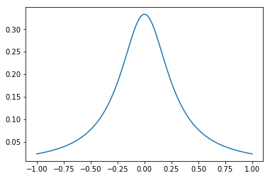

```python
import matplotlib.pyplot as plt

x = np.linspace(-1.0, 1.0, 100)
fx = list(map(f, x))

plt.plot(x, fx)
plt.show()
```

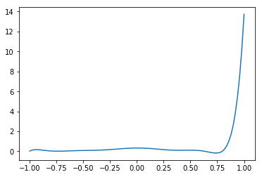

```python
xx = np.arange(-1, 1, 0.2)
fx_lagr = list(map(f, xx))
lagr_f = list(map(lambda p: L(xx, fx_lagr, p), x))
plt.plot(x, lagr_f)
plt.show()
```

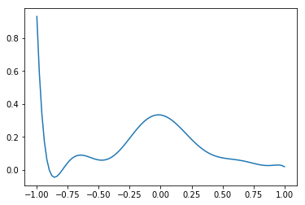

```python
n = 10
chebyshev_nodes = [chebyshev(i, n) for i in range(n)]
fx_cheb = list(map(f, chebyshev_nodes))
lagr_chebyshev = list(map(lambda xx: L(chebyshev_nodes, fx_cheb, xx), x))

plt.plot(x, lagr_chebyshev)
plt.show()
```

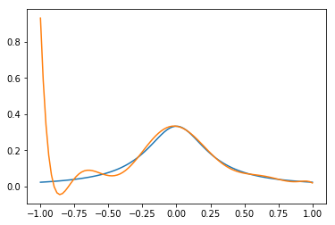

```python
plt.plot(x, fx, x, lagr_chebyshev)
plt.show()
```

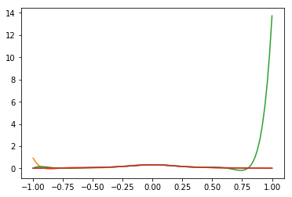

```python
plt.plot(x, fx, x, lagr_chebyshev,x, lagr_f, x, fx)
plt.show()
```